# Analyzing NFL Play Data

### Jake Richard, CMSC320 Final Project

Since the NFL was formed in 1920, the game of football has changed a lot. Teams in the NFL who are successful not only have the most talented and well-trained athletes, but also have great coaches who innovate the game with new strategies on offense and defense. Over time, different styles of offense and defense have emerged dominant in different stages of the game.

In the early life of the NFL, handing the ball off to the running back was the primary option on offense. Teams then began to develop a passing game. The quarterback's role became more and more important, and teams with the right quaterback and wide receivers were able to win. Many teams didn't know the best ways to defend against the pass.

In today's NFL, teams are built around franchise quarterbacks, with pass heavy offenses complemented by a steady ground game in order to always keep the defense on it's toes.

When most of the professional sports leagues started keeping statistics on everything about the game, coaches and players began to gain more insight on various game situations. In every play, there's a decision to be made about what play your offense/defense is going to execute, and many more factors that determine the outcome of that play.

In this tutorial, I will analyze play data from 2009 - 2017, and look for some interesting insights I can find in four areas:  
Total Yardage  
Run vs. Pass  
4th Down Situations  
Field Goals vs. Extra Points

## Background

Here's some reading on the basic rules of football if you need a refresher:  
https://www.thoughtco.com/football-101-the-basics-of-football-1333784

Here's a quick video if you don't like to read:  
https://www.youtube.com/watch?v=3t6hM5tRlfA

### Tools

Here's some of the python tools I'll be using:  
Requests Pandas  
Numpy  
Seaborn

```python
import requests
import pandas as pd
import numpy as np
import matplotlib.pyplot as plt
import seaborn as sns
import math
import re
from sklearn import preprocessing
import warnings
warnings.filterwarnings('ignore')
```

## Dataset

The data set I will be using can be found on Kaggle.com: https://www.kaggle.com/maxhorowitz/nflplaybyplay2009to2016/version/5#NFL%20Play%20by%20Play%202009-2017%20(v4).csv

Each row in the dataset is for each play during each game. There are a lot of columns in the csv, 102 to be exact, for a lot of different things such as the date, the gameID, the down, the yard line, yards to go, play attempted, yards gained, and many more.

```python
df = pd.read_csv("nflplaybyplay2009to2016/NFLPlaybyPlay20092017v4.csv", encoding='utf-8')
```

## NFL Yardage

First, we'll look at total yardage overall. This is an important statistic because it gives some general sense on what the states of offense and defense are in the league. More yards means more productive offenses, and less yards means more productive defenses

We'll filter the plays in the dataset to only pass and run plays (else we would also get punts, 2 point conversions, field goals, and extra points) and calculate the total yardage per year:

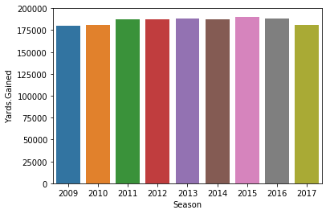

```python
RunsAndPasses = df[(df["PlayType"] == "Pass") | (df["PlayType"] == "Run")]
YardsPerPlay = RunsAndPasses[["Date", "down", "ydstogo", "PlayType", "Yards.Gained", "Touchdown", "Season"]]

YardsPerSeason = YardsPerPlay.groupby(["Season"], as_index=False).sum()
sns.barplot(x="Season", y="Yards.Gained", data=YardsPerSeason)
```

From the data that we have in this set, we see relatively uniform yardage per year, with a slight increase until 2015 then a two-year decrease. If we had more data from years before 2009, I suspect we would see a general increase in total yardage

## Yardage: Running vs. passing:

Next, we'll look at running vs passing overall

Using our split pass and run play data we can compare total yards gained between both types of plays per season

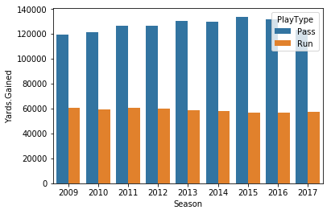

```python
YardsPerSeason = YardsPerPlay.groupby(["Season","PlayType"], as_index=False).sum()
sns.barplot(x="Season", y="Yards.Gained", hue="PlayType", data=YardsPerSeason)
```

In this plot we can see clearly that pass plays are producing more yards. Over time we also see a small decrease in run yardage with a small increase in pass yardage, which makes more sense as quarterbacks are becoming more prominent than ever

## Touchdowns: running vs. passing:

Let's see what plays tend to score more touchdowns

Using our split pass and run play data we can filter only the plays that have scored touchdowns and compare the differences per season

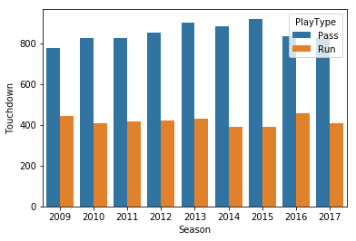

```python
Touchdowns = RunsAndPasses[RunsAndPasses["Touchdown"] == 1]
Touchdowns = Touchdowns[["Date", "down", "PlayType", "Yards.Gained", "Touchdown", "Season"]]
TouchdownsPerSeason = Touchdowns.groupby(["Season", "PlayType"], as_index=False).sum()
sns.barplot(x="Season", y="Touchdown", hue="PlayType", data=TouchdownsPerSeason)
```

This seems to be very similar to our pass vs. rush yardage situation. Let's see if there's a relationship between the two

### Pass / Rush Touchdown and Yardage Ratio:

Next I'll take the ratio of passing touchdowns to rushing touchdowns and compare it to to ratio of passing yards to rushing yards.

Lets start with the Pass/Rush touchdown Ratio. We'll normalize the ratios so we can compare them easier

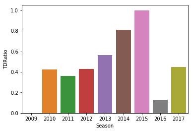

```python
min_max_scaler = preprocessing.MinMaxScaler()

PassTD = TouchdownsPerSeason[TouchdownsPerSeason["PlayType"] == "Pass"]
RushTD = TouchdownsPerSeason[TouchdownsPerSeason["PlayType"] == "Run"]
PassTD = PassTD.rename(index=str, columns={"Touchdown": "PassTD"})
PassTD["RushTD"] = RushTD.Touchdown.values
PassTD=PassTD.drop(columns=["PlayType"])
PassTD["TDRatio"] = PassTD["PassTD"]/PassTD["RushTD"]
PassTD["TDRatio"] = min_max_scaler.fit_transform(PassTD["TDRatio"].values.reshape(-1,1))

sns.barplot(x="Season", y="TDRatio", data=PassTD)
```

Now we'll compare pass/run yardage ratios

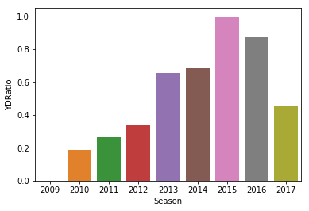

```python
PassYD = YardsPerSeason[YardsPerSeason["PlayType"] == "Pass"]
RushYD = YardsPerSeason[YardsPerSeason["PlayType"] == "Run"]
PassYD = PassYD.rename(index=str, columns={"Yards.Gained": "PassYD"})
PassYD["RushYD"] = RushYD["Yards.Gained"].values
PassYD=PassYD.drop(columns=["PlayType"])
PassYD["YDRatio"] = PassYD["PassYD"]/PassYD["RushYD"]
PassYD["YDRatio"] = min_max_scaler.fit_transform(PassYD["YDRatio"].values.reshape(-1,1))
sns.barplot(x="Season", y="YDRatio", data=PassYD)
```

Except for the year 2016, These ratios appear to be pretty similar. This shows that pass/run ratios and pass/run touchdown ratios tend to match up from year to year, which conceptually makes sense but is an interesting statistic

## Situational Statistics

The amount of yards to go and the current down both have a large impact on the play that is called. Many teams opt to run the ball on first down, but lately we have seen more teams throw the ball on each down. Which play style is more effective? In this section I'll explore how passing or running the ball on first down can help or hurt your team.

First, I'll find the perentage of times that each team decides to pass the ball on first down

I'll have to cross reference another data set in order to get win/loss data for all the teams since win/loss data is not included in the play by play data, so that's why there's a lot of code in this section

```python
FirstDownPlays = RunsAndPasses[RunsAndPasses["down"] == 1]

FirstDownPlays = FirstDownPlays[["Date", "down", "PlayType", "posteam"]]
FirstDownPlays = FirstDownPlays.groupby(["posteam", "PlayType"], as_index=False).sum()

FirstPass = FirstDownPlays[FirstDownPlays["PlayType"] == "Pass"]
FirstRush = FirstDownPlays[FirstDownPlays["PlayType"] == "Run"]

FirstPass = FirstPass.rename(index=str, columns={"down": "numPass"})
FirstPass["numRush"] = FirstRush["down"].values
FirstPass = FirstPass.drop(columns=["PlayType"])
FirstPass = FirstPass.reset_index()

FirstPass.at[15, "numPass"] = FirstPass.iloc[15].numPass + FirstPass.iloc[14].numPass
FirstPass.at[15, "numRush"] = FirstPass.iloc[15].numRush + FirstPass.iloc[14].numRush

FirstPass.at[31, "numPass"] = FirstPass.iloc[31].numPass + FirstPass.iloc[17].numPass
FirstPass.at[31, "numRush"] = FirstPass.iloc[31].numRush + FirstPass.iloc[17].numRush

FirstPass.at[28, "numPass"] = FirstPass.iloc[28].numPass + FirstPass.iloc[18].numPass
FirstPass.at[28, "numRush"] = FirstPass.iloc[28].numRush + FirstPass.iloc[18].numRush

FirstPass = FirstPass.drop([14,17,18])

FirstPass["PercentPass"] = (FirstPass["numPass"]/(FirstPass["numRush"]+FirstPass["numPass"]))*100

FirstPass[["posteam","PercentPass"]]
```

|  | posteam | PercentPass |
| --- | --- | --- |
| 0 | ARI | 49.653045 |
| 1 | ATL | 48.864758 |
| 2 | BAL | 48.315448 |
| 3 | BUF | 42.581682 |
| 4 | CAR | 44.887526 |
| 5 | CHI | 47.282898 |
| 6 | CIN | 44.642857 |
| 7 | CLE | 47.612661 |
| 8 | DAL | 46.444781 |
| 9 | DEN | 47.550220 |
| 10 | DET | 50.074257 |
| 11 | GB | 49.131767 |
| 12 | HOU | 46.784487 |
| 13 | IND | 51.529709 |
| 15 | JAX | 49.053628 |
| 16 | KC | 44.275210 |
| 19 | MIA | 48.849511 |
| 20 | MIN | 43.372549 |
| 21 | NE | 49.941602 |
| 22 | NO | 52.380952 |
| 23 | NYG | 49.066599 |
| 24 | NYJ | 39.326425 |
| 25 | OAK | 50.066085 |
| 26 | PHI | 52.906693 |
| 27 | PIT | 48.900126 |
| 28 | SD | 46.640020 |
| 29 | SEA | 46.324696 |
| 30 | SF | 46.072302 |
| 31 | STL | 44.616219 |
| 32 | TB | 47.754886 |
| 33 | TEN | 46.462715 |
| 34 | WAS | 47.159672 |

In the above table we can see the percentage of pass plays on first down for each team over the 9 year period, now we'll cross reference our team win-loss data.

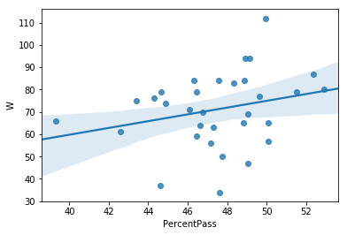

```python
TeamData = pd.read_csv("TeamData20092017.csv", encoding='utf-8')
TeamData = TeamData.replace("\+", "", regex=True)
TeamData = TeamData.replace("\*", "", regex=True)
TeamData = TeamData.groupby("Tm", as_index=False).sum()
TeamData["Team"] = ["ARI", "ATL", "BAL", "BUF", "CAR", "CHI", "CIN", "CLE", "DAL", "DEN", "DET", "GB", "HOU", "IND", "JAX", "KC", "LAC", "LA", "MIA", "MIN", "NE", "NO", "NYG", "NYJ", "OAK", "PHI", "PIT", "SD", "SF", "SEA", "STL", "TB", "TEN", "WAS"]

MergeData = FirstPass.merge(TeamData, left_on="posteam", right_on="Team")
sns.regplot('PercentPass', 'W', data=MergeData)
```

In this plot we see the number of wins with respect to the percentage of pass plays on first down. We can fit a regression line to this dataset which comes out with a small positive slope, indicating there might be some merit to passing on first down.

### 4th Down Situations

When it's fourth down, is it smarter to go for it or punt the ball/take a field goal? Let's analyze the outcomes of fouth down situations from our data.

Here we filter the data to only the run/pass plays that happen on fourth down, with the yards to go as well as the outcome of the play

```python
FourthDownPlays = RunsAndPasses[RunsAndPasses["down"] == 4]
FourthDownPlays = FourthDownPlays[["PlayType", "posteam", "ydstogo", "Yards.Gained", "desc"]]

FourthDownFails = FourthDownPlays[FourthDownPlays["Yards.Gained"] < FourthDownPlays["ydstogo"]]
FourthDownWins = FourthDownPlays[FourthDownPlays["Yards.Gained"] >= FourthDownPlays["ydstogo"]]

numFails = FourthDownFails.shape[0]
numWins = FourthDownWins.shape[0]

percentConvert = numWins/(numFails+numWins)
percentConvert
```

```
0.504238314361831
```

So it seems out of all fourth down attempts, the first down is achieved about 50% of the time. What about when there is more than 10 yards to go?

```python
FourthDownPlays = RunsAndPasses[RunsAndPasses["down"] == 4]
FourthDownPlays = FourthDownPlays[["PlayType", "posteam", "ydstogo", "Yards.Gained", "desc"]]

FourthDownPlays = FourthDownPlays[FourthDownPlays["ydstogo"] > 10]

FourthDownFails = FourthDownPlays[FourthDownPlays["Yards.Gained"] < FourthDownPlays["ydstogo"]]
FourthDownWins = FourthDownPlays[FourthDownPlays["Yards.Gained"] >= FourthDownPlays["ydstogo"]]

numFails = FourthDownFails.shape[0]
numWins = FourthDownWins.shape[0]

percentConvert = numWins/(numFails+numWins)
percentConvert
```

```
0.2211764705882353
```

When there are more than 10 yards to go, the first down is achieved about 22% of the time.

In fact, we can model the conversion chance based on how many yards a team as left to the first down marker

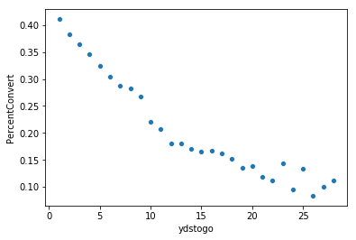

```python
FourthDownPlays = RunsAndPasses[RunsAndPasses["down"] == 4]
FourthDownPlays = FourthDownPlays[["PlayType", "posteam", "ydstogo", "Yards.Gained", "desc"]]

def calcPercentConvert(ydstogo):
    FourthDownydstogo = FourthDownPlays[FourthDownPlays["ydstogo"] > ydstogo]

    FourthDownFails = FourthDownydstogo[FourthDownydstogo["Yards.Gained"] < FourthDownydstogo["ydstogo"]]
    FourthDownWins = FourthDownydstogo[FourthDownydstogo["Yards.Gained"] >= FourthDownydstogo["ydstogo"]]

    numFails = FourthDownFails.shape[0]
    numWins = FourthDownWins.shape[0]

    if (numWins+numFails != 0):
        percentConvert = numWins/(numFails+numWins)
    else:
        percentConvert = 0
    return percentConvert

ydstogoConvert = pd.DataFrame(columns=["ydstogo", "PercentConvert"], dtype='float')
for i in range(0,28):
    newdf = pd.DataFrame([[i + 1, calcPercentConvert(i+1)]], columns=["ydstogo", "PercentConvert"])
    ydstogoConvert = ydstogoConvert.append(newdf)

ydstogoConvert = ydstogoConvert.reset_index()
sns.scatterplot("ydstogo", "PercentConvert", data=ydstogoConvert)
```

Let's see what a regression line looks like for this dataset and try and gain more insight

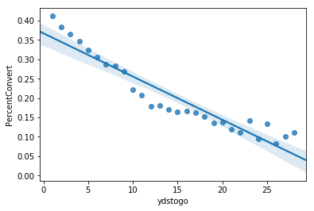

```python
sns.regplot("ydstogo", "PercentConvert", data=ydstogoConvert)
```

From this model, we can see how likely we would be able to convert on fourth down given how many yards we need to gain, however the linear model doesn't fit perfectly. Let's try and fit a logistic model and see what works better

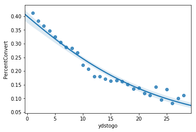

```python
sns.regplot("ydstogo", "PercentConvert", data=ydstogoConvert, logistic=True)
```

It appears this logistic curve works a little better in modeling our data. We see a fairly steep decrease in conversion percentage that slowly levels out at between 10%-15%.

### Field Goals vs. Extra points

Prior to the 2015 season, when an extra point was attempted, the ball was snapped at the two yard line, which led to about a 19 yard extra point kick. At the start of the 2015 season, the extra point attempt snap was moved back to the 15 yard line, which created a 33 yard extra point kick. Inituitively, this move back would seem to lower the percentage of completed extra points, but lets look at the numbers.

First we'll compare the kick completion percentages from the old extra point kick to the new extra point kicks

```python
OldExtraPoints = df[(df["PlayType"] == "Extra Point") & (df["Season"] < 2015)]
NewExtraPoints = df[(df["PlayType"] == "Extra Point") & (df["Season"] >= 2015)]
OldExtraPoints = OldExtraPoints[["PlayType", "posteam", "ExPointResult", "desc"]]
NewExtraPoints = NewExtraPoints[["PlayType", "posteam", "ExPointResult", "desc"]]

MissedOldExtraPoints = OldExtraPoints[(OldExtraPoints["ExPointResult"] == "Missed")]
MadeOldExtraPoints = OldExtraPoints[OldExtraPoints["ExPointResult"] == "Made"]
OldMade = MadeOldExtraPoints.shape[0]
OldMiss = MissedOldExtraPoints.shape[0]
OldMakePercentage = OldMade/(OldMiss+OldMade)

MissedNewExtraPoints = NewExtraPoints[(NewExtraPoints["ExPointResult"] == "Missed")]
MadeNewExtraPoints = NewExtraPoints[NewExtraPoints["ExPointResult"] == "Made"]
NewMade = MadeNewExtraPoints.shape[0]
NewMiss = MissedNewExtraPoints.shape[0]
NewMakePercentage = NewMade/(NewMiss+NewMade)

print("Old Extra Points: \nMade: "+ str(OldMade) +"\nMissed: "+ str(OldMiss) + "\nPercent Made: " + str(OldMakePercentage) + "\n")
print("New Extra Points: \nMade: "+ str(NewMade) +"\nMissed: "+ str(NewMiss) + "\nPercent Made: " + str(NewMakePercentage) + "\n")
print("Completion Percentage Differece: " + str(OldMakePercentage-NewMakePercentage))
```

```
Old Extra Points:
Made: 6690
Missed: 20
Percent Made: 0.9970193740685543

New Extra Points:
Made: 3119
Missed: 152
Percent Made: 0.9535310302659737

Completion Percentage Differece: 0.0434883438025806
```

Looking at the data above we can see that the closer extra points were more successful, in fact there's a 4.3% decrease in extra point completion percentage. How do field goals from around the 15 yard line compare? Is there a difference in completion percentage if we're attempting a field goal vs. an extra point? Here I'll take field goal data from kicks between 30 and 35 yards out, and compare the completion percentage to extra points from 33 yards:

```python
FieldGoals = df[df["PlayType"] == "Field Goal"]
FieldGoals = FieldGoals[["PlayType", "posteam", "FieldGoalDistance", "FieldGoalResult", "desc"]]
FieldGoalsSimilar = FieldGoals[(FieldGoals["FieldGoalDistance"] <= 35) & (FieldGoals["FieldGoalDistance"] >= 30)]

FieldGoalsMade = FieldGoalsSimilar[FieldGoalsSimilar["FieldGoalResult"] == "Good"]
FieldGoalsMissed = FieldGoalsSimilar[FieldGoalsSimilar["FieldGoalResult"] == "No Good"]
Made = FieldGoalsMade.shape[0]
Missed = FieldGoalsMissed.shape[0]
MakePercentage = Made / (Made+Missed)

print("Field Goals between 30-35 yards: \nMade: "+ str(Made) +"\nMissed: "+ str(Missed) + "\nPercent Made: " + str(MakePercentage) + "\n")
```

```
Field Goals between 30-35 yards:
Made: 1401
Missed: 95
Percent Made: 0.9364973262032086
```

This begs the question, how does the distance impact the field goal completion percentage? We can create code similar to our fourth down calculations and graph the percentages against the distance.

The closest field goal we can take is around 18-19 yards (10 for the end zone, 7 for the snap, and 1 or 2 for the distance from the goal line). The longest field goal that has been completed in regulation is 63 yards, but in recent history the longest is 62. So we'll work with distances 19-62 yards out

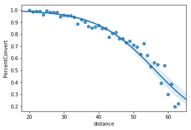

```python
def calcFGPercentConvert(distance):
    FieldGoalsDist = FieldGoals[(FieldGoals["FieldGoalDistance"] == distance)]

    FieldGoalsMade = FieldGoalsDist[FieldGoalsDist["FieldGoalResult"] == "Good"]
    FieldGoalsMissed = FieldGoalsDist[FieldGoalsDist["FieldGoalResult"] == "No Good"]

    Made = FieldGoalsMade.shape[0]
    Missed = FieldGoalsMissed.shape[0]

    if (Made+Missed != 0):
        percentConvert = Made/(Made+Missed)
    else:
        percentConvert = 0
    return percentConvert

calcPercentConvert(21)

FieldGoalCompletion = pd.DataFrame(columns=["distance", "PercentConvert"], dtype='float')
for i in range(19,63):
    newdf = pd.DataFrame([[i + 1, calcFGPercentConvert(i+1)]], columns=["distance", "PercentConvert"])
    FieldGoalCompletion = FieldGoalCompletion.append(newdf)

FieldGoalCompletion = FieldGoalCompletion.reset_index()
sns.regplot("distance", "PercentConvert", data=FieldGoalCompletion, logistic=True)
```

This data looks more logarithmic, and we see a pretty steep decrease in field goal completion percentage when the field goal distance is longer than 40 yards

## Conclusions

Throughout this project, we've looked at a lot of different statistics related to football.

From our yardage data, I think that it would have been interesting to see data from more seasons than I have. If I was able to find yardage data from a coulpe decades back, we would have some more interesting yardage calculations. A lot of NFL data (Besides win-loss data) is fairly new, and so it's tough to track total yardage with just the 9 years of data we have.

Viewing the data from a coach's perspective, there were a few interesting takeaways from my data analysis. First, passing the ball on first down is not a bad option. I think there are balances into establishing a good run game, but there is some merit to starting a series off with some high yards chances as shown by the data.

I think it's interesting that field goals from similar distances to extra points are made less. I think it mainly has to do with the higher pressure of field goal situations in games that cause kickers to slip up. The push back of the extra point has been a little but controversial, but overall it's been working in making the scoring more variable and we can see the impacts that this is having in the stats. When it comes to attempting field goals, I would advise anything under 40 yards to be a pretty safe bet. We slowly decrease 50% field goal completion rate as the distance approaches about 55 yards. Kicks from 60+ yards out are fairly unlikely, so I'd tread carefully when thinking about taking kicks from that distance.

Overall, It comes down to the ability of the players and coaches to work together and make the best decisions for their teams and execute those plays to help their team succeed. These statistics can help coaches and players understand how their role on and off the field impacts the game in every situation.